# Modeling Swire Coca Cola

### 4.3. Model Evaluation Through Visualizations and Insights

#### 4.3.1. How does machine age correlate with failure rates?

You can visualize the relationship between machine age and failure rate using a scatter plot or boxplot. This will allow you to explore how failure rates vary with increasing machine age.

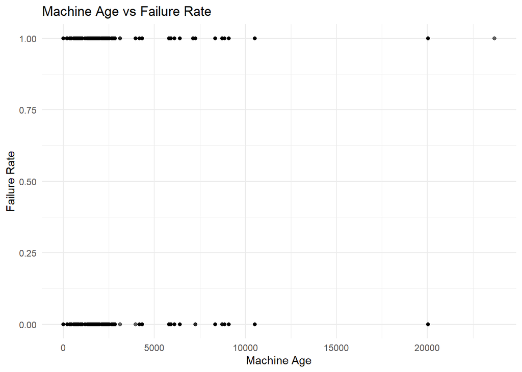

```r
# Scatter plot to visualize machine age vs failure rate
library(ggplot2)
ggplot(data, aes(x = MACHINE_AGE, y = Failure)) +
  geom_point(alpha = 0.6) +
  labs(title = "Machine Age vs Failure Rate", x = "Machine Age", y = "Failure Rate") +
  theme_minimal()
```

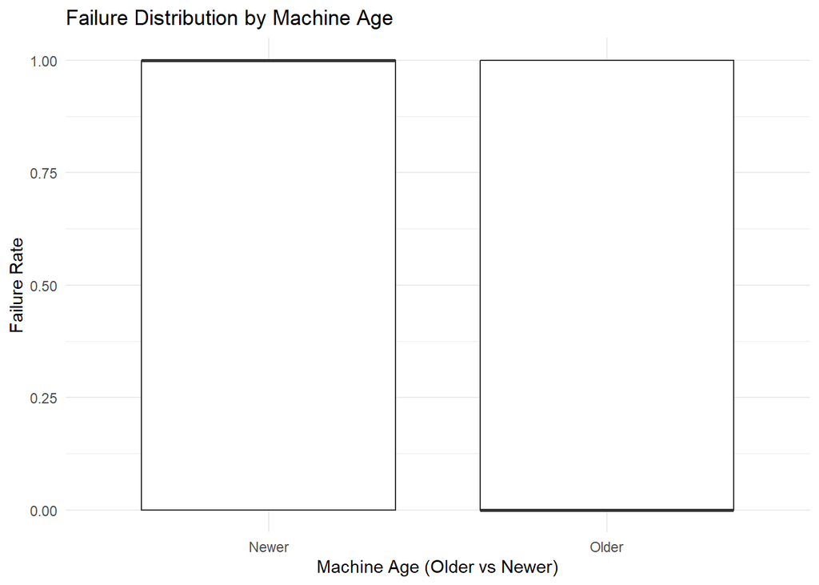

```r
# Boxplot to see failure distribution by machine age
ggplot(data, aes(x = factor(MACHINE_AGE > threshold), y = Failure)) +
  geom_boxplot() +
  labs(title = "Failure Distribution by Machine Age", x = "Machine Age (Older vs Newer)", y = "Failure Rate") +
  scale_x_discrete(labels = c("Newer", "Older")) +
  theme_minimal()
```

#### 4.3.2. Which models perform better when predicting failures in older vs. newer machines?

Create a bar plot to compare the model accuracies (Logistic Regression vs. XGBoost) for both older and newer machines.

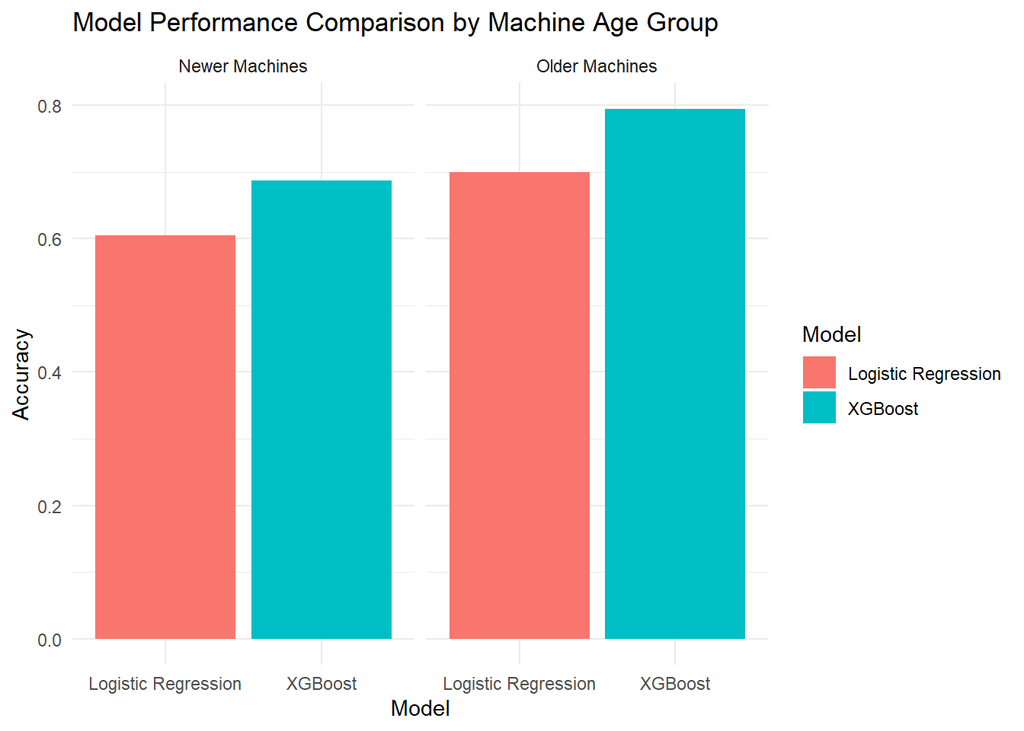

```r
# Visualization of model comparison for older and newer machines
library(ggplot2)
model_comparison <- data.frame(
  Model = rep(c("Logistic Regression", "XGBoost"), 2),
  Accuracy = c(logistic_accuracy_older, xgb_accuracy_older, logistic_accuracy_newer, xgb_accuracy_newer),
  Age_Group = rep(c("Older Machines", "Newer Machines"), each = 2)
)

ggplot(model_comparison, aes(x = Model, y = Accuracy, fill = Model)) +
  geom_bar(stat = "identity", position = "dodge") +
  facet_wrap(~ Age_Group) +
  labs(title = "Model Performance Comparison by Machine Age Group", x = "Model", y = "Accuracy") +
  theme_minimal()
```

#### 4.3.3. How do maintenance activities, machine age, and other factors influence failure predictions in different age groups?

Create a feature importance plot for the XGBoost model to determine which features are contributing most to failure predictions. You can also visualize the correlation between different factors and failure predictions.

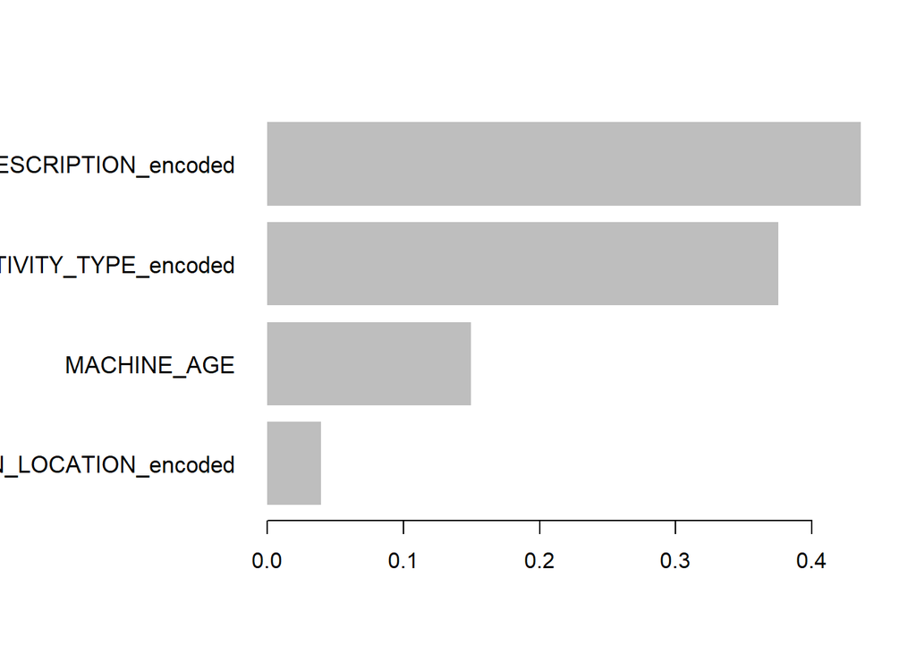

```r
# XGBoost feature importance plot
xgb_importance <- xgb.importance(model = xgb_older_model)
xgb.plot.importance(xgb_importance)
```

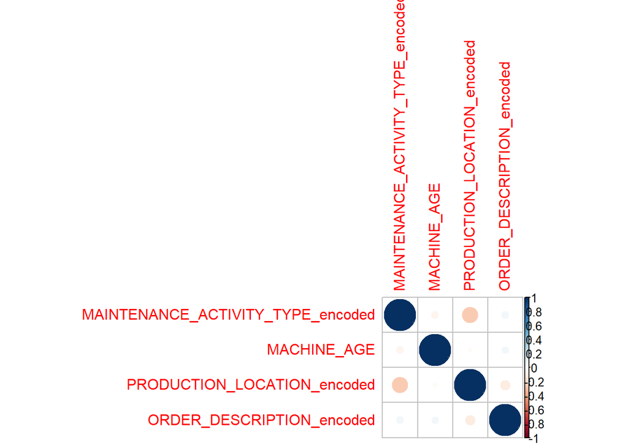

```r
# Correlation plot between features
library(corrplot)
correlation_matrix <- cor(older_machines_data[, c("MAINTENANCE_ACTIVITY_TYPE_encoded", "MACHINE_AGE", "PRODUCTION_LOCATION_encoded", "ORDER_DESCRIPTION_encoded")])
corrplot(correlation_matrix, method = "circle")
```

#### 4.3.4. What operational strategies can be implemented for older machines?

To explore operational strategies, use the insights from your model performance comparison. For example, you could visualize the predicted probabilities of failure for older machines and plot the optimal thresholds to prioritize maintenance based on predicted failure risks.

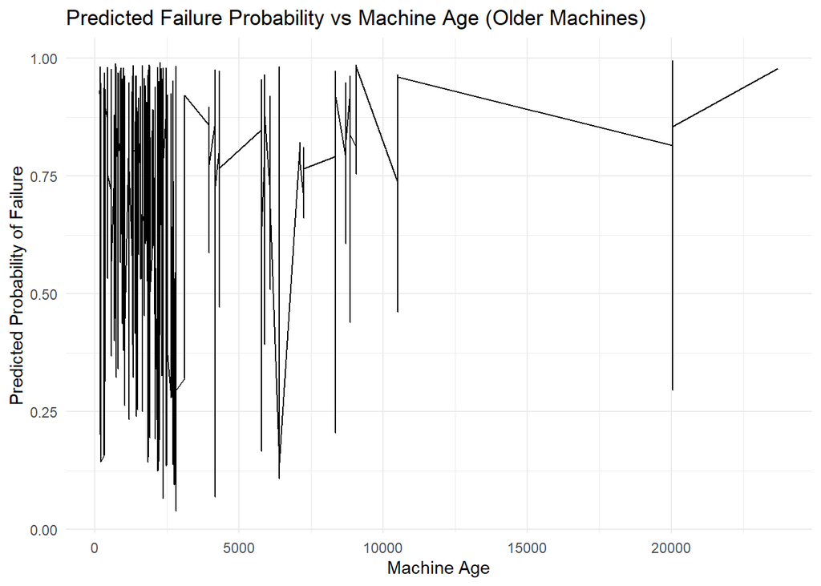

```r
# Plot predicted probabilities for older machines
pred_prob_older <- predict(xgb_older_model, newdata = xgb_older_data)
ggplot(data.frame(Machine_Age = older_machines_data$MACHINE_AGE, Predicted_Prob = pred_prob_older),
       aes(x = Machine_Age, y = Predicted_Prob)) +
  geom_line() +
  labs(title = "Predicted Failure Probability vs Machine Age (Older Machines)", x = "Machine Age", y = "Predicted Probability of Failure") +
  theme_minimal()
```

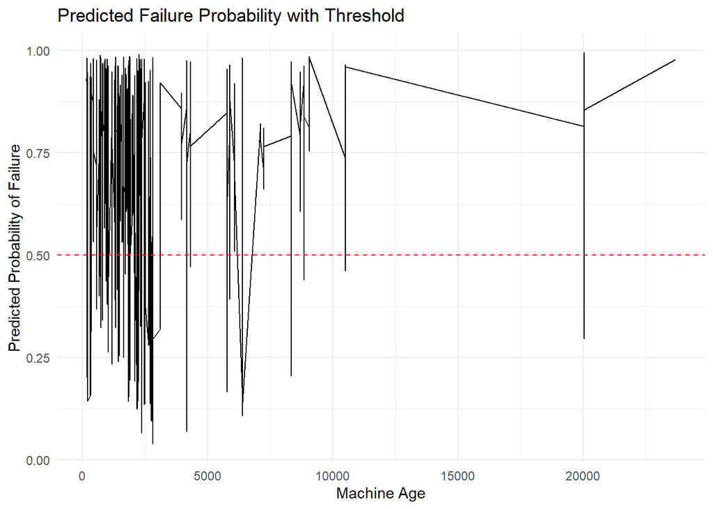

```r
# Adding a threshold line for decision-making
threshold <- 0.5  # Example threshold for deciding failure risk
ggplot(data.frame(Machine_Age = older_machines_data$MACHINE_AGE, Predicted_Prob = pred_prob_older),
       aes(x = Machine_Age, y = Predicted_Prob)) +
  geom_line() +
  geom_hline(yintercept = threshold, linetype = "dashed", color = "red") +
  labs(title = "Predicted Failure Probability with Threshold", x = "Machine Age", y = "Predicted Probability of Failure") +
  theme_minimal()
```

#### 4.3.5. ROC Curve: Compare the model’s performance with respect to true positive and false positive rates.

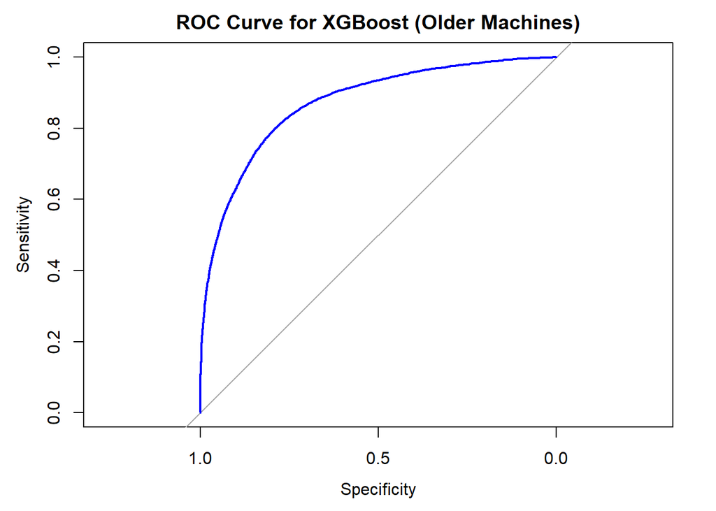

```r
# ROC Curve for XGBoost (Older Machines)
library(pROC)
roc_curve_older <- roc(older_machines_data$Failure, xgb_pred_older)
plot(roc_curve_older, main = "ROC Curve for XGBoost (Older Machines)", col = "blue")
```

#### 4.3.6. Precision-Recall Curve: This is useful in imbalanced classification problems (e.g., failure prediction).

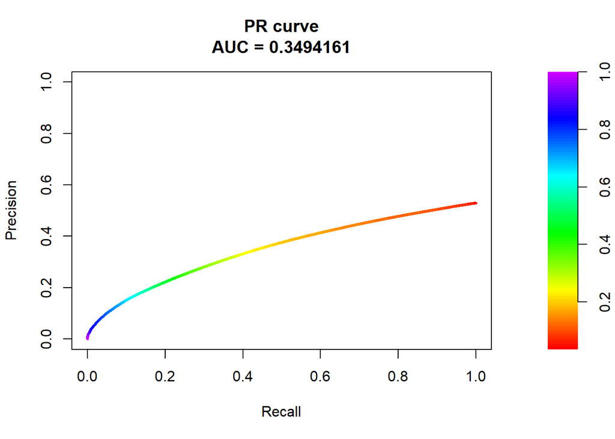

```r
# Precision-Recall curve for XGBoost (Older Machines)
library(PRROC)
pr_curve_older <- pr.curve(scores.class0 = xgb_pred_older[older_machines_data$Failure == 0],
                           scores.class1 = xgb_pred_older[older_machines_data$Failure == 1],
                           curve = TRUE)
plot(pr_curve_older)
```